# Stringmol run analysis

# prelims

Set the `froot` variable to the path to the files for these tests:

```r
#froot="D:/sjh/stringmol/out3smsp/"
froot="D:/sjh/stringmol/smsp/1705smsp/out5/"
#froot="~/Desktop/paulien/sm250r/out3/"
```

# Popdy

```r
source("../R/plot_onepop.R")
plot.onepop(sprintf("%spopdy001.dat",froot),"example1popdy.pdf",12,12,minpop=100, totpop=T,plotnspp = T)
```

```
the condition has length > 1 and only the first element will be used
```

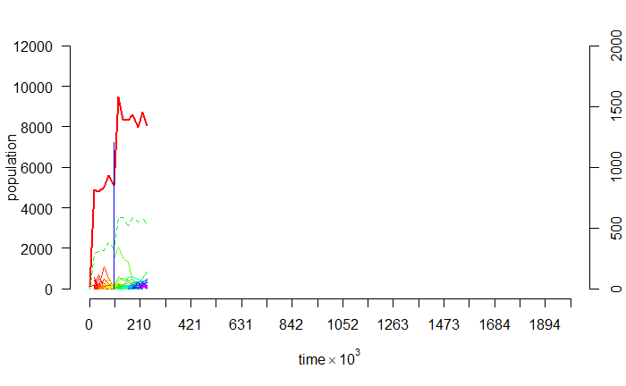

```r
segments(x0=100000,y0=0,y1=1200,col="blue")
```

Concerns: - this only records pop every 10000 timesteps - potentially many generations between recordings. Understandable though - if we find a particular feature, we can go back and rerun to get more detail. - Nothing here about species length - need to grab that info from the right spplists file - Need a sanity check on the species numbers via the spplists (since we are purging these).

# Community structure

## stats

### Stats from `splist` files

Theres a function called `splist_stats` that grabs the data from the files - let’s check it out:

```r
source("../R/splist_stats.R")
sps <- splist_stats(sprintf("%ssplist100000.dat",froot),tmin=90000)
```

This gives us a data frame holding every reaction seen until this point (assuming no restarts).

That works, so let’s see if we can do an iteration:

```r
gotdata<- T
tstep <- 20000 #sometimes its 10000
tt <- tstep
sps <- list()
nsps <- 1
while(gotdata){
  fn <- sprintf("%ssplist%d.dat",froot,tt)
  if(file.exists(fn)){
    message(sprintf("\nProcessing Time %d:",tt))
    sps[[nsps]] <- splist_stats(fn,tmin=(tt-10000))
    nsps <- nsps + 1
  }
  else
    gotdata <- F

  tt = tt+tstep
}
```

```
Processing Time 20000:

Processing Time 40000:

Processing Time 60000:

Processing Time 80000:

Processing Time 100000:

Processing Time 120000:

Processing Time 140000:

Processing Time 160000:

Processing Time 180000:

Processing Time 200000:

Processing Time 220000:

Processing Time 240000:
RESTART DETECTED - check file D:/sjh/stringmol/smsp/1705smsp/out5/splist240000.dat

Processing Time 260000:

Processing Time 280000:

Processing Time 300000:

Processing Time 320000:

Processing Time 340000:

Processing Time 360000:

Processing Time 380000:

Processing Time 400000:
```

[output cut: 164 more lines]

```
Processing Time 1880000:

Processing Time 1900000:

Processing Time 1920000:
RESTART DETECTED - check file D:/sjh/stringmol/smsp/1705smsp/out5/splist1920000.dat

Processing Time 1940000:

Processing Time 1960000:

Processing Time 1980000:
RESTART DETECTED - check file D:/sjh/stringmol/smsp/1705smsp/out5/splist1980000.dat

Processing Time 2000000:
```

### Stats from `.conf` files

If we want the commonest reaction at time x, we might be better to look at the out1*conf files - these are a snapshot of the current system by definition - these will take a little more work to interpret however, but they will be exact. We might even be able to use these to develop a network of what is going on…

Each entry for a reaction in the current state of the system looks like this:

```
%%% REACTION 718
REACTION
###############  8557 WWGEWLHHHRLUEUWJJJRNJXUUUDGRGJLRWWRE$BLUBO^B>C$=?>$$BLUBO%}OYHOB
REACTION_ACTIVE  8557 WWGEWLHHHRLUEUWJJJRNJXUUUDGRGJLRWWRE$BLUBO^B>C$=?>$$BLUBO%}OYHOBWWGEWLHHHRLUEUWJJJRNJXUUUDGRGJ irwf: 1 0 49 0 30 16 1 0 94 1 0 46 grid: 165 39  pass_index: 1629

PASSIVE
REACTION_PASSIVE 8557 WWGEWLHHHRLUEUWJJJRNJXUUUDGRGJLRWWRE$BLUBO^B>C$=?>$$BLUBO%}OYHOB grid: 166 40
###############  8557 WWGEWLHHHRLUEUWJJJRNJXUUUDGRGJLRWWRE$BLUBO^B>C$=?>$$BLUBO%}OYHOB

AGENT  JJRNJXUUUDGRHJLRWWRE$BLUBO^>C$=?>$$BUBOUB$=?>$$=?>$$BLUBO%}OYHOB 1 Q
GRIDPOS  190 30

AGENT  $BLUBO^>C$=?>$$BUBOUBO^B>C$=?>$$BLUBO%}OYHOB 1 Q
GRIDPOS  189 29
```

Let’s try some code that looks at these records to try to build a picture of what’s going on at any particular time. First, we’ll get each reaction:

```r
require (stringr)
source("../R/splist_stats.R")
####Function 'arguments'
  fn <- sprintf("%sout1_100000.conf",froot)
  verbose <- T
  spldata <-  splist_stats(sprintf("%ssplist100000.dat",froot))
####Function 'body'
  cf <- read.table(fn,as.is = T, fill = T, sep="\n",comment.char="",stringsAsFactors = F)

  #get the row number of the start of each reaction entry
  rpos <- which(str_sub(cf[,1],1,12)=="%%% REACTION")

  nr <- length(rpos)
  actno <- vector(length = nr)
  actseq <- vector(length = nr)
  pasno <- vector(length = nr)
  passeq <- vector(length = nr)
```

```r
  #build the data for each reaction - similar to the splist analysis
  #This introduces NAs by coercion sometimes
  for(rr in 1:nr){
    words <-strsplit(cf[rpos[rr]+2,1],split=" ")
    actno[rr] <- as.numeric(words[[1]][3])
    actseq[rr] <- words[[1]][4]
    words <-strsplit(cf[rpos[rr]+6,1],split=" ")
    pasno[rr] <- as.numeric(words[[1]][3])
    passeq[rr] <- words[[1]][4]
    #message(sprintf("Active  molecule %s seq %s",actno[rr],actseq[rr]))
    #message(sprintf("Passive molecule %s seq %s",actno[rr],actseq[rr]))
  }

  eachreaction<-data.frame(actno,actseq,pasno,passeq)

  #summarize each reaction with the active and passive reactants (note we aren't assuming a different product...)
  reactions <- unique(eachreaction)
  reactions$type = "<unknown>"
  for(rr in 1:nrow(reactions)){
    ca <- eachreaction[eachreaction$actno == reactions$actno[rr] & eachreaction$pasno == reactions$pasno[rr],]
    reactions$count[rr] = nrow(ca)
  }
  reactions <- reactions[order(reactions$count,decreasing = T),]

  #Get the product molecule from the splist:
  for(rr in 1:nrow(reactions)){

    #Check for NAs in the species numbers:
    if(is.na(reactions$actno[rr]) || is.na(reactions$pasno[rr])){

        #message(sprintf("Reaction %d has NAs  (NA)",rr))
        reactions$type[rr]= "na"
        next
    }

    #Get all reactions with the same active and passive spp
    dd <- spldata[(spldata$act == reactions$actno[rr]) & (spldata$pass == reactions$pasno[rr]), ]
    if(nrow(dd)==0){
      #message(sprintf("Reaction %d has no product (NP)",rr))
      reactions$type[rr]= "NP"
    }
    if(reactions$actno[rr] == reactions$pasno[rr]){
      if(nrow(dd)==1){
        if(dd$spp == reactions$actno[rr]){
          #message(sprintf("Reaction %d is an exact self:self replicator (ER)*",rr))
          reactions$type[rr]= "ER"
        }
        else{
          #message(sprintf("Self:self reaction with different product (DP)*",rr))
          reactions$type[rr]= "DP"
        }
      }
      if(nrow(dd)>1){
        #message(sprintf("Reaction %d is a pathological replicator (PR)",rr))
        reactions$type[rr]= "PR"
      }
    }
    else{
      if(nrow(dd)==1){
        if(dd$spp == reactions$pasno[rr]){
          #message(sprintf("Reaction %d is parsitic (PA)*",rr))
        reactions$type[rr]= "PA"
        }
        else{
          #message(sprintf("non-self reaction with different product (DN)*",rr))
          reactions$type[rr]= "DN"
        }
      }
      if(nrow(dd)>1){
        #message(sprintf("Reaction %d is a pathological non-self replicator (PN)",rr))
        reactions$type[rr]= "PN"
      }
    }


  }
```

Check that we’ve now got this in a function:

```r
source("../R/splist_stats.R")
source("../R/rconf_stats.R")
source("../R/rconf_data.R")
reactions <- rconf_stats(fn = sprintf("%sout1_100000.conf",froot), spfn = sprintf("%ssplist100000.dat",froot))
```

Now we can count the different reaction types:

```r
reactions <- rconf_stats(fn = sprintf("%sout1_400000.conf",froot), spfn = sprintf("%ssplist400000.dat",froot))
rclass <- c("NA","NP","ER","DP","PR","PA","DN","PN")
rcounts <- data.frame(rclass)
for(rr in 1:length(rclass)){
  dd <- reactions[reactions$type == rclass[rr],]
  rcounts$count[rr] = nrow(dd)
}
rcounts
```

[output not shown]

That works, so let’s see if we can do an iteration:

```r
source("../R/splist_stats.R")
source("../R/rconf_stats.R")

gotdata<- T
tt <- 20000
#rcounts <- data.frame(rclass)
rcounts <- data.frame(time=0,"NA"=0,NP=0,ER=1,DP=0,PR=0,PA=0,DN=0,PN=0)
rsumcounts <- data.frame(time=0,"NA"=0,NP=0,ER=500,DP=0,PR=0,PA=0,DN=0,PN=0)
count <- vector(length = length(rclass))
scount <- vector(length = length(rclass))
count <- 0
sumcount <- 0
rno<-2

while(gotdata ){#&& tt < 320000){#
  fn <- sprintf("%ssplist%d.dat",froot,tt)
  spfn <- sprintf("%sout1_%d.dat",froot,tt)
  if(file.exists(fn)){
    message(sprintf("\nProcessing Time %d:",tt))
    #reactions <- rconf_stats(fn = sprintf("%sout1_%d.conf",froot,tt),
    #                         spfn = sprintf("%ssplist%d.dat",froot,tt),verbose=F)
    reactions <- rconf_stats_nosplist(fn = sprintf("%sout1_%d.conf",froot,tt),
                                      #spfn = sprintf("%ssplist%d.dat",froot,tt),
                                      verbose=T)

    #message("\n\nout\n\n")

    if(is.null(dim(reactions))){#nrow(reactions)==0){
    }
    else{

      count <- 0
      sumcount <- 0

      for(rr in 1:length(rclass)){

        dd <- reactions[reactions$type == rclass[rr],]
        count[rr] <- nrow(dd)
        sumcount[rr] <- sum(dd$count)
      }
      #assign(sprintf("t%d",tt))

      trow = c(tt,t(count))
      rcounts <- rbind(rcounts,trow)

      trow = c(tt,t(sumcount))
      rsumcounts <- rbind(rsumcounts,trow)
      #colnames(rcounts)[rno] <- sprintf("t%d",tt)

      #rno <- rno + 1
    }

  }
  else{
    gotdata <- F
  }
  tt = tt+20000
  #if(tt > 50000)gotdata <- F
}
#Now we can plot the change in diversity:
#https://www.r-graph-gallery.com/stacked-barplot/
```

```r
bcols = rainbow(ncol(rcounts[2:9]))
bcols <- bcols[sample(1:length(bcols))]
par(mfrow=c(2,1))
barplot(t(rcounts[2:9]),col=bcols,border=bcols,names=rcounts[,1],las=2,main="Reaction Types")
cn <-colnames(rcounts)

#NB! This is not currently automatically ordered correctly..
cnlong <- c("Pathological non-self replicator",
            "Non-self reaction; different product",
            "Parasitic",
            "Pathological replicator",
            "self-self; different product",
            "self-self; exact replicator",
            "No Product",
            "Unclassified")

legend("topleft",legend=sprintf("%s %s",rev(cn[2:9]),cnlong),fill=rev(bcols),border=rev(bcols),cex = 0.5)

barplot(t(rsumcounts[2:9]),col=bcols,border=bcols,names=rcounts[,1],las=2,main="Reaction Counts")
cn <-colnames(rcounts)

legend("topleft",sprintf("%s %s",rev(cn[2:9]),cnlong),fill=rev(bcols),border=rev(bcols),cex = 0.5)
#legend("topleft",legend=(cn[2:9]),fill=(bcols),border=(bcols))
```

[output not shown]

## Handling the warnings…

let’s look at t=80000 again and make sure we are handling warnings properly.

```r
source("../R/splist_stats.R")
source("../R/rconf_data.R")
source("../R/rconf_stats.R")
tt <- 80000
spfn = sprintf("%ssplist%d.dat",froot,tt)
spldata <-  splist_stats(spfn)

fn = sprintf("%sout1_%d.conf",froot,tt)
#rcd <- rconf_rdata(fn,verbose=T)


reactions <- rconf_stats(fn, spfn, verbose = F)
```

## Changes in community structure over time